# Autoencoders for Dimensionality Reduction

```
159/159 ━━━━━━━━━━━━━━━━━━━━ 0s 1ms/step
```

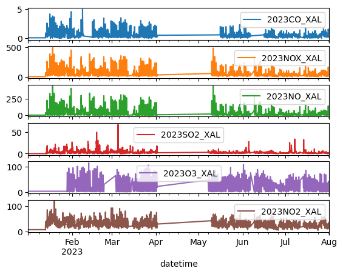

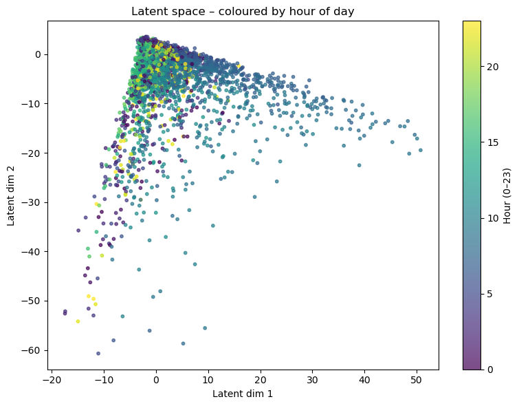

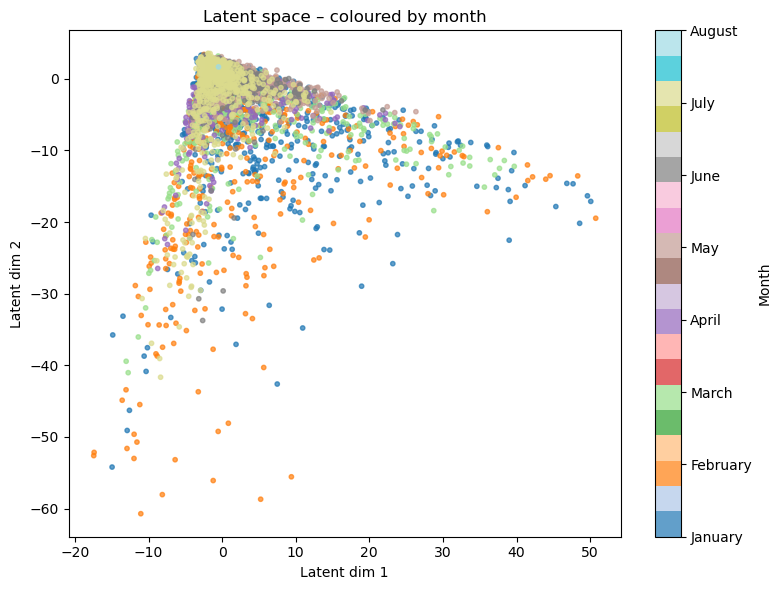

```
159/159 ━━━━━━━━━━━━━━━━━━━━ 0s 2ms/step
```

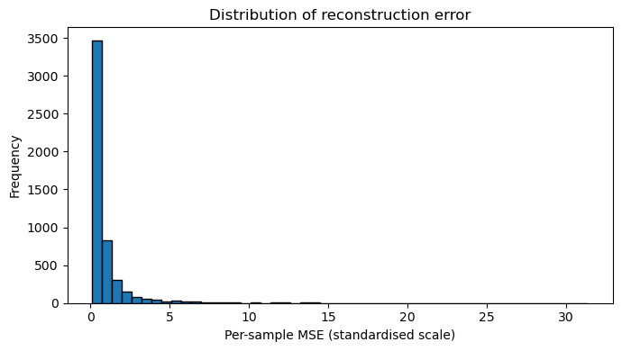

```python
wide.index = pd.to_datetime(wide.index)
wide.filter(like='_XAL').plot(subplots=True)


X_full     = wide.values
X_full_std = scaler.transform(X_full)

Z_full     = encoder.predict(X_full_std)

emb_df = pd.DataFrame({
    "z1": Z_full[:, 0],
    "z2": Z_full[:, 1],
    "datetime": wide.index
})
emb_df["hour"]  = emb_df["datetime"].dt.hour
emb_df["month"] = emb_df["datetime"].dt.month_name()

# scatter plot hours
plt.figure(figsize=(8, 6))
plt.scatter(emb_df["z1"], emb_df["z2"],
            c=emb_df["hour"], cmap="viridis", s=10, alpha=0.7)
plt.xlabel("Latent dim 1"); plt.ylabel("Latent dim 2")
plt.title("Latent space – coloured by hour of day")
plt.colorbar(label="Hour (0–23)")
plt.tight_layout(); plt.show()


#Scatter by month
month_to_int = {m: i for i, m in enumerate(emb_df["month"].unique())}
month_ints   = emb_df["month"].map(month_to_int)

plt.figure(figsize=(8, 6))
plt.scatter(emb_df["z1"], emb_df["z2"],
            c=month_ints, cmap="tab20", s=10, alpha=0.7)
plt.xlabel("Latent dim 1"); plt.ylabel("Latent dim 2")
plt.title("Latent space – coloured by month")
cbar = plt.colorbar(ticks=list(month_to_int.values()))
cbar.ax.set_yticklabels(list(month_to_int.keys()))
cbar.set_label("Month")
plt.tight_layout(); plt.show()

# hist
X_recon = ae.predict(X_full_std)
mse     = np.mean(np.square(X_recon - X_full_std), axis=1)

plt.figure(figsize=(7, 4))
plt.hist(mse, bins=50, edgecolor="black")
plt.xlabel("Per-sample MSE (standardised scale)")
plt.ylabel("Frequency")
plt.title("Distribution of reconstruction error")
plt.tight_layout(); plt.show()
```

```python
station_code = "XAL"

cols_this_station = [c for c in wide.columns if c.endswith("_" + station_code)]
wide_station = wide[cols_this_station]
```

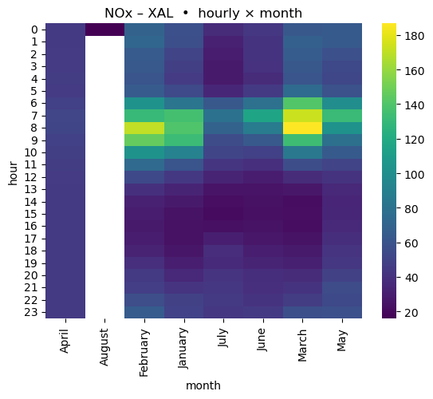

```python
wide_station["hour"]  = wide_station.index.hour
wide_station["month"] = wide_station.index.month_name()

heat = (wide_station
        .groupby(["month","hour"])
        .mean()
        .unstack("month"))

import seaborn as sns
sns.heatmap(heat[ "2023NOX_XAL" ], cmap="viridis")
plt.title("NOx – XAL  •  hourly × month")
plt.show()
```

## Conclusion

- The 2-D latent space captures **shared variance across pollutants and stations**, organising normal conditions into a dense core and pushing rare combinations into the periphery.
- Colour-by-hour plots show only mild diurnal gradients, suggesting that **station-to-station or weekly factors dominate over hourly cycles** once data are robustly scaled.
- Seasonal separation is weak in two dimensions; a higher-rank latent space (e.g. 4–5 D) or variable-specific models could reveal clearer month-wise arcs.
- Reconstruction-error histograms help **surface potential outliers**: timestamps with MSE far above the median coincide with spikes or periods of missing / imputed data.
- For further insight one could
  1. train **single-pollutant autoencoders** to isolate diurnal rhythms,
  2. aggregate hourly means and cluster stations by their 24-h fingerprints, or
  3. apply sequence models (LSTM-AE) to detect short-lived pollution episodes.

Overall, the project demonstrates how *autoencoders provide an efficient, unsupervised lens* on multivariate environmental data, balancing dimensionality reduction, anomaly detection, and exploratory visualisation in a single framework.